# What I wish I knew when I started using R

Coding Club

June 29, 2017

## Trick 1: A proposition of workflow

1. Use R-projects within R-studio
2. Use git and github (integrated in R-studio) to save versions of you scripts and enable to return to older versions within your project. On top of that github allow sharing and collaborating.
3. Structure your project in a logical way eg. 3.1 folder ‘data’ that contains the raw data 3.2 one script to create usable datafiles from the raw data 3.3 one script (or a folder with scripts) that contains the functions you will be using often. 3.4 folder with R-notebooks to do your analysis and exploration. Every notebook starts with loading the required packages for the session and loading all datatables and functions using the source() command. 3.5 folder with output documents that can be ignored by git.

[notebooks](http://rmarkdown.rstudio.com/r_notebooks.html): interactive coding that shows graphs and output from analyses between the code chunks. Automatically generates a nicely output in html format that can be sent to external people.

Source: runs all the code from an r-file you call. write as: source(“name_of_R_script.R”)

## Trick 2: Using the tidyverse

dplyr, tidyr, ggplot2, best tools to work with large datasets. Have a look at the many nice [cheatsheets](https://www.rstudio.com/resources/cheatsheets/). [tidyr](https://cran.r-project.org/web/packages/tidyr/index.html) make data tidy for using in [dplyr](https://cran.r-project.org/web/packages/dplyr/index.html), using this structure you can use [ggplot2](https://cran.r-project.org/web/packages/ggplot2/index.html), even in interactive mode with [plotly](https://plot.ly/ggplot2/). ggplot2 is the best for data exploration. For publication-ready figures base plot function may be better.

## Trick 3: The predict function

You fitted a model and you want to get the model predicted values.

```r
dat <- data.frame(x=runif(100,-2,2))
dat$y <- rnorm(100,1+2*dat$x,1)
m <- lm(y~x,dat)

#before
pred <- coef(m)[1] + coef(m)[2]*dat$x

#after
pred_p <- predict(m)
pred == pred_p
```

```
##     1     2     3     4     5     6     7     8     9    10    11    12
##  TRUE  TRUE  TRUE  TRUE FALSE FALSE  TRUE FALSE  TRUE  TRUE FALSE  TRUE
##    13    14    15    16    17    18    19    20    21    22    23    24
##  TRUE  TRUE  TRUE  TRUE  TRUE  TRUE  TRUE  TRUE FALSE FALSE  TRUE  TRUE
##    25    26    27    28    29    30    31    32    33    34    35    36
##  TRUE  TRUE  TRUE  TRUE FALSE FALSE  TRUE  TRUE FALSE  TRUE  TRUE FALSE
##    37    38    39    40    41    42    43    44    45    46    47    48
##  TRUE  TRUE  TRUE FALSE  TRUE  TRUE FALSE FALSE FALSE  TRUE  TRUE  TRUE
##    49    50    51    52    53    54    55    56    57    58    59    60
##  TRUE  TRUE  TRUE  TRUE FALSE  TRUE  TRUE FALSE  TRUE  TRUE  TRUE FALSE
##    61    62    63    64    65    66    67    68    69    70    71    72
##  TRUE  TRUE  TRUE FALSE FALSE FALSE FALSE  TRUE FALSE  TRUE FALSE  TRUE
##    73    74    75    76    77    78    79    80    81    82    83    84
## FALSE FALSE  TRUE  TRUE  TRUE  TRUE  TRUE  TRUE FALSE FALSE FALSE FALSE
##    85    86    87    88    89    90    91    92    93    94    95    96
##  TRUE  TRUE  TRUE FALSE FALSE FALSE FALSE FALSE  TRUE FALSE  TRUE  TRUE
##    97    98    99   100
## FALSE  TRUE  TRUE  TRUE
```

## Trick 4: Create functions

Create functions when using always the same code. Example with a plotting function to plot (ggplot2) specific columns in a dataframe. Learned through googling and [stackoverflow](https://stackoverflow.com/questions/tagged/r), we will have a session on this coming soon!

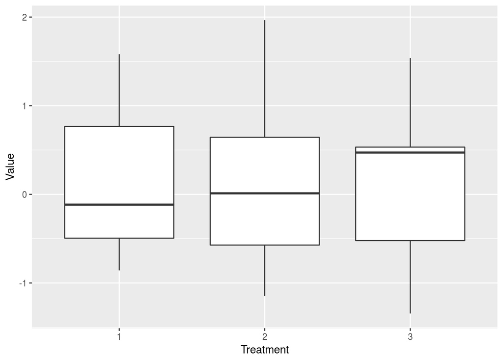

```r
visvar <- function(Var,data){
  g <- ggplot(data,aes_string(x="Treatment",y=Var))+geom_boxplot()
  return(g)
}

dat <- data.frame(Treatment=gl(n = 3,k = 10),Value=rnorm(30))
visvar("Value",dat)
```

We continued with a discussion of using for-loops, see [this](https://www.r-bloggers.com/how-to-write-the-first-for-loop-in-r/) blog post, but [beware](https://biologyforfun.wordpress.com/2013/02/13/the-day-i-stoped-using-for-loops-in-r/) of efficiency issues, one could also use the __ply functions (see ?apply, ?plyr etc)

## Trick 5: Vectorization

R automatically does operations on entire vectors.

```r
x <- rep(1,10)
y <- rep(2,10)

#without vectorization
for(i in 1:10) print(x[i] + y[i])
```

```
## [1] 3
## [1] 3
## [1] 3
## [1] 3
## [1] 3
## [1] 3
## [1] 3
## [1] 3
## [1] 3
## [1] 3
```

```r
#with vectorization
x + y
```

```
##  [1] 3 3 3 3 3 3 3 3 3 3
```

```r
#beware of internal R tricks
x + c(1,2)
```

```
##  [1] 2 3 2 3 2 3 2 3 2 3
```

```r
x + c(1,2,3)
```

```
##  [1] 2 3 4 2 3 4 2 3 4 2
```

## Trick 6: Ifelse

A useful function, return specific values depending on a logical statement. This is a vectorized if…else statement which is faster than writing a loop.

```r
x<-runif(10,-2,2)
ifelse(x<0,"Yes","No")
```

```
##  [1] "No"  "No"  "No"  "Yes" "No"  "Yes" "Yes" "No"  "No"  "No"
```

## Trick 7: Functions as object

Functions are object like everything else and can be passed around, like functions within functions, more on this in a further session.

```r
f <- function(n){
  return(rep(10,n))
}
f(10) + 1
```

```
##  [1] 11 11 11 11 11 11 11 11 11 11
```

## Trick 8: Logical statement as numbers

In R you can compute stuff from logical, for instance if you want to count how many element in a vector are bigger than 10 you can use:

```r
(x<-rpois(10,10))
```

```
##  [1]  9  5 10  9  8 14 10 11  7 12
```

```r
sum(x>10)
```

```
## [1] 3
```

## Trick 9: expand.grid

This function will generated a data frame repeating all values of one variables against all values of another variables (like in a fully factorial design).

```r
(newdat <- expand.grid(Treatment=c("Low","Medium","High"),Light=1:10))
```

```
##    Treatment Light
## 1        Low     1
## 2     Medium     1
## 3       High     1
## 4        Low     2
## 5     Medium     2
## 6       High     2
## 7        Low     3
## 8     Medium     3
## 9       High     3
## 10       Low     4
## 11    Medium     4
## 12      High     4
## 13       Low     5
## 14    Medium     5
```

[output cut: 16 more lines]

## Trick 10: model.matrix

This is a similar function that gives you the model matrix from a formula, very useful if you want to go deeper into simulations and understanding of linear models.

```r
dat <- data.frame(Treatment=gl(n = 3,k=10),Light=runif(30))
(modmat <- model.matrix(~Treatment*Light,dat))
```

```
##    (Intercept) Treatment2 Treatment3      Light Treatment2:Light
## 1            1          0          0 0.30196401       0.00000000
## 2            1          0          0 0.36838963       0.00000000
## 3            1          0          0 0.45614123       0.00000000
## 4            1          0          0 0.63076753       0.00000000
## 5            1          0          0 0.49584110       0.00000000
## 6            1          0          0 0.87181924       0.00000000
## 7            1          0          0 0.47538920       0.00000000
## 8            1          0          0 0.01903315       0.00000000
## 9            1          0          0 0.57244678       0.00000000
## 10           1          0          0 0.91058417       0.00000000
## 11           1          1          0 0.53508946       0.53508946
## 12           1          1          0 0.43833701       0.43833701
## 13           1          1          0 0.12825976       0.12825976
## 14           1          1          0 0.01786302       0.01786302
```

[output cut: 52 more lines]

## Trick 11: shinyHeatmaply

Have a look at [this package](https://www.r-statistics.com/2017/03/shinyheatmaply-a-shiny-app-for-creating-interactive-cluster-heatmaps/) for interactive construction of heatmaps.

Other option for similar plots pairs.panels in the psych package or corrplot in the [corrplot](https://cran.r-project.org/web/packages/corrplot/index.html) package

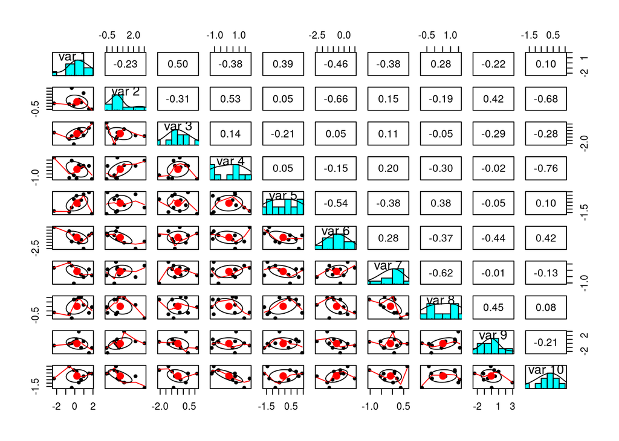

```r
#example 1 with psych
library(psych)
pairs.panels(matrix(rnorm(100),ncol=10))
```

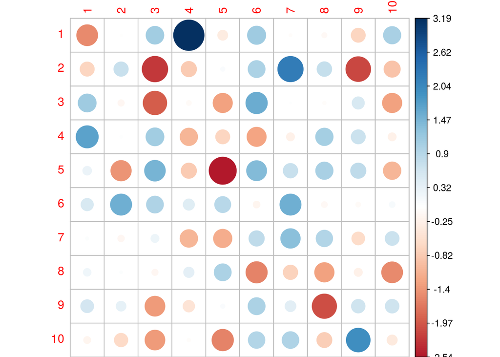

```r
#example with corrplot
library(corrplot)
corrplot(matrix(rnorm(100),ncol=10),is.corr=FALSE)
```

## Trick 12: with

Please [don’t use attach](https://www.r-bloggers.com/to-attach-or-not-attach-that-is-the-question/)! Use rather the with function which tells R where to look for some variables, it avoids you to use $ or [].

```r
dat <- data.frame(x=rnorm(10),y=rnorm(10))
with(dat,cor(x,y))
```

```
## [1] -0.1187447
```

## Trick 13: by

Apply a function to chuncks of data, similar to tapply, dplyr and others …

```r
dat <- data.frame(x=rnorm(30),y=rnorm(30),Treatment=gl(n = 3,k = 10))
#get the maximum from the x column
by(dat$x,dat$Treatment,max)
```

```
## dat$Treatment: 1
## [1] 1.233624
## --------------------------------------------------------
## dat$Treatment: 2
## [1] 1.830944
## --------------------------------------------------------
## dat$Treatment: 3
## [1] 1.402927
```

```r
#get the mean per treatment
by(dat[,1:2],dat$Treatment,function(x) apply(x,2,mean))
```

```
## dat$Treatment: 1
##         x         y
## 0.0452227 0.2747563
## --------------------------------------------------------
## dat$Treatment: 2
##         x         y
## 0.1828918 0.0783298
## --------------------------------------------------------
## dat$Treatment: 3
##          x          y
##  0.2974303 -0.5838823
```

## Trick 14: Quickly update your models

From a fitted model you can easily remove (-) or add (+) variables and compute a new model, all in one line. Update works this way: (i) provide a fitted model (model_1), (ii) specify how the model formula should change, you can use the symbol “.” which means “all variables”.

```r
dat <- data.frame(x1=rnorm(10),x2=rnorm(10), x3=rnorm(10), x4=rnorm(10), y=rnorm(10) )
F1 <- formula(y ~ x1 + x2 +x3)
model_1 <- lm(F1, data=dat)
# you can add or remove variables from the object with 'update()'
model_2 <- update(model_1,.~.-x3)
model_3 <- update(model_1,.~.+x4)

summary(model_1)
```

```
##
## Call:
## lm(formula = F1, data = dat)
##
## Residuals:
##     Min      1Q  Median      3Q     Max
## -1.3371 -0.2738 -0.1148  0.1191  1.3353
##
## Coefficients:
##             Estimate Std. Error t value Pr(>|t|)
## (Intercept)  0.02493    0.33870   0.074    0.944
## x1          -0.11116    0.33501  -0.332    0.751
## x2          -0.03848    0.25136  -0.153    0.883
## x3           0.36370    0.19410   1.874    0.110
##
## Residual standard error: 0.8727 on 6 degrees of freedom
## Multiple R-squared:  0.4163, Adjusted R-squared:  0.1244
## F-statistic: 1.426 on 3 and 6 DF,  p-value: 0.3247
```

```r
summary(model_2)
```

```
##
## Call:
## lm(formula = y ~ x1 + x2, data = dat)
##
## Residuals:
##     Min      1Q  Median      3Q     Max
## -1.1375 -0.5537 -0.1099  0.3280  1.9485
##
## Coefficients:
##             Estimate Std. Error t value Pr(>|t|)
## (Intercept)  -0.2715     0.3491  -0.778    0.462
## x1           -0.2617     0.3791  -0.690    0.512
## x2            0.0287     0.2900   0.099    0.924
##
## Residual standard error: 1.017 on 7 degrees of freedom
## Multiple R-squared:  0.0747, Adjusted R-squared:  -0.1897
## F-statistic: 0.2825 on 2 and 7 DF,  p-value: 0.7621
```

```r
summary(model_3)
```

```
##
## Call:
## lm(formula = y ~ x1 + x2 + x3 + x4, data = dat)
##
## Residuals:
##        1        2        3        4        5        6        7        8
##  0.05777 -0.62572 -0.29668  0.43213 -0.36773 -0.09961 -0.59001  0.89025
##        9       10
##  0.43845  0.16115
##
## Coefficients:
##             Estimate Std. Error t value Pr(>|t|)
## (Intercept) -0.43275    0.32170  -1.345   0.2364
## x1          -0.01506    0.25640  -0.059   0.9554
## x2           0.11456    0.20079   0.571   0.5930
## x3          -0.05729    0.23165  -0.247   0.8145
## x4           0.93441    0.39804   2.348   0.0658 .
## ---
## Signif. codes:  0 '***' 0.001 '**' 0.01 '*' 0.05 '.' 0.1 ' ' 1
##
## Residual standard error: 0.6593 on 5 degrees of freedom
## Multiple R-squared:  0.7223, Adjusted R-squared:  0.5002
## F-statistic: 3.252 on 4 and 5 DF,  p-value: 0.114
```

# For the next session

Talk from Frederik: About loops and functions (20min) + exercise

Further session from Bram: How to make your code more efficient